# Motor Trend Research

Ana Baraldi

November 22, 2015

## What’s better for your miles per galon (mpg): an automatic or a manual car?

### Summary

Before we read our data, we are going to load the required libraries and set the global options for the data analysis and regression modeling.

```r
library(ggplot2)
library(knitr)
library(GGally)
```

```r
opts_chunk$set(fig.align = "center")
options(scipen = 1, digits = 2)
```

To begin our analysis, we are going to check the dataset dimension.

```r
dim <- dim(mtcars)
```

As we can see our dataset has 32 cars analyzed and 11 different variables measured. Also, lets check out which variables we are dealing with:

```r
names(mtcars)
```

```
##  [1] "mpg"  "cyl"  "disp" "hp"   "drat" "wt"   "qsec" "vs"   "am"   "gear"
## [11] "carb"
```

Here we are interested in the relation between the transmission type (manual or automatic), but before we check only the relation between `mpg` and `am` (the column with the transmission information), we can see how the others variables are related with `mpg` with a paired plot. You can check it out in the Appendix (Figure 1).

As we can see we have a lot of `factor` variables, as `cyl` that measures how many cylinders he have, `gear` that measures the number of forward gears and our desired information: if the car is automatic or manual is also a `factor` variable.

I could have done some further analysis between all the other variables and our outcome (`mpg`), but I have prefered to focus in the main relationship: transmission type and miles per galon. That’s why I haven’t done any linear model with the other infomation. We can see those relationship in our Figure 2, a boxplot with the information of `mpg` in the different cars.

Just to make sure our variable is treated the right way, I’ve modified the dataset to make sure `am` is a `factor`. As `0` is for automatic cars and `1` is for manual cars.

So, I’ve defined my linear model as `fit`. My outcome is `mpg` and my predictor `am`.

```r
fit <- lm(mpg ~ am, mtcars)
```

Here are the summary of our model:

```
##
## Call:
## lm(formula = mpg ~ am, data = mtcars)
##
## Residuals:
##    Min     1Q Median     3Q    Max
## -9.392 -3.092 -0.297  3.244  9.508
##
## Coefficients:
##             Estimate Std. Error t value Pr(>|t|)
## (Intercept)    17.15       1.12   15.25  1.1e-15 ***
## am1             7.24       1.76    4.11  0.00029 ***
## ---
## Signif. codes:  0 '***' 0.001 '**' 0.01 '*' 0.05 '.' 0.1 ' ' 1
##
## Residual standard error: 4.9 on 30 degrees of freedom
## Multiple R-squared:  0.36,   Adjusted R-squared:  0.338
## F-statistic: 16.9 on 1 and 30 DF,  p-value: 0.000285
```

As we are talking about a `factor` variable, our coefficient interpretation is a little different from the others linear models. Our `intercept` represents the information around our first level of information, in the case, the automatic cars. To interpret the other coefficient we have to think about it as the sum of itself with the `intercept`. In our case, the `intercept` is 17.15, and it represents the mean for the automatic cars. To understand the information for the manual cars, we have to sum the `intercept` and `am1`, which is 24.39.

With that information we can finish our analysis, to understand all the impact in `mpg` we have to look for the other variables in dataset, but with the research we have done here we can see exclusively the relationship between the transmission type and the miles per galon.

## Appendix

### Figure 1

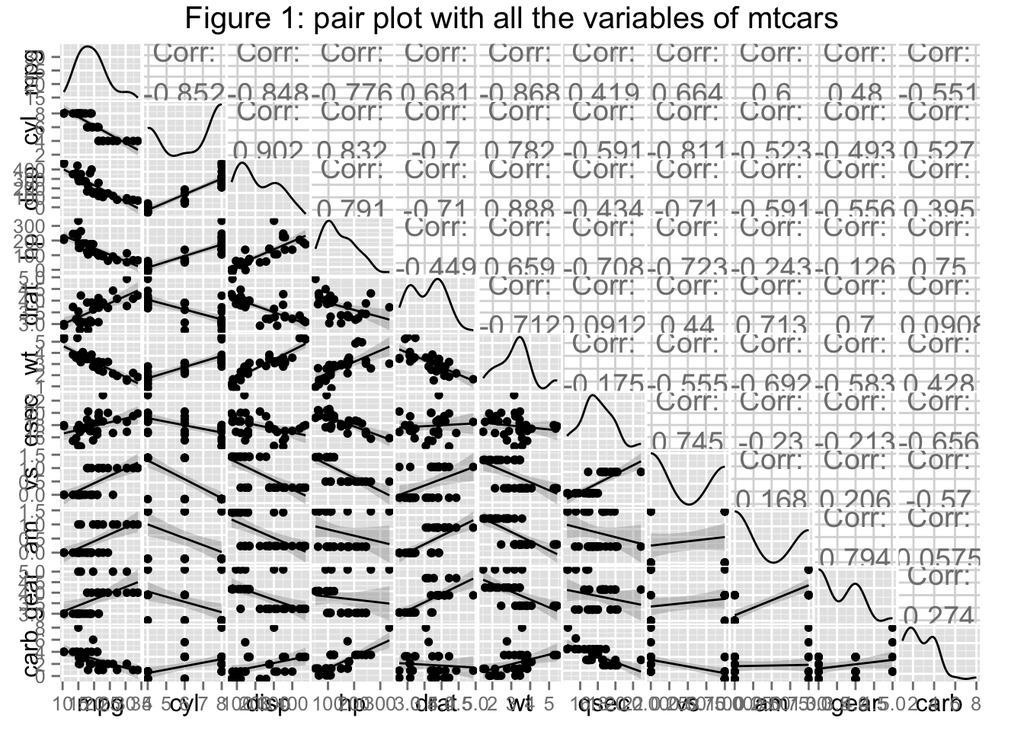

### Figure 2

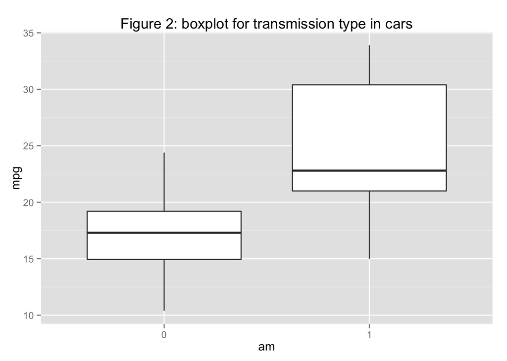